# LUC Reconstruction Analysis in Hector

Pablo Tomberlin

2025-07-24

Hello! Here’s my land-use change (LUC) emissions analysis project using Hector, a simple earth system model. Follow along to see my work.

Please copy-paste these links into a browser to download all the data, then move them to the same location as your Hector_Projections_LUC.Rmd file

https://docs.google.com/spreadsheets/d/e/2PACX-1vQ2vJjvywy-PRBGbAd7G9L2CmjT9grbajOk4A093SMdEPbjj88UNP0_PbtY2K84bwNJENkwwoVDocVj/pub?gid=1941860215&single=true&output=csv

https://docs.google.com/spreadsheets/d/e/2PACX-1vRjs-hhzm1kJpETetq66_kfY1A2srEvj3Eeo905weC70VpNGP1gIm1JYSyCuh9qeWZru6VisRb1IXRP/pub?gid=117143989&single=true&output=csv

https://docs.google.com/spreadsheets/d/e/2PACX-1vQiHGo6rLp8D9opUDTYOR5uiTzHyY0w92irwIIDbsRYRk4bdON5dDyjyN2uJ76X5QVKuu4jK42o1HGh/pub?gid=128021618&single=true&output=csv

Read in data and load necessary packages

```r
data <- read.csv("selected_GCP.csv")
data_FF <- read.csv("Fossil_Fuels.csv")
observations <- read.csv("GML_observations.csv")
library(tidyverse)
library(Metrics)
library(ggsci)
library(ggrepel)
data <- data %>% filter(!(is.na(year)))
```

Fossil fuel visualization of a lengthening time series(2014, 2019, 2024)

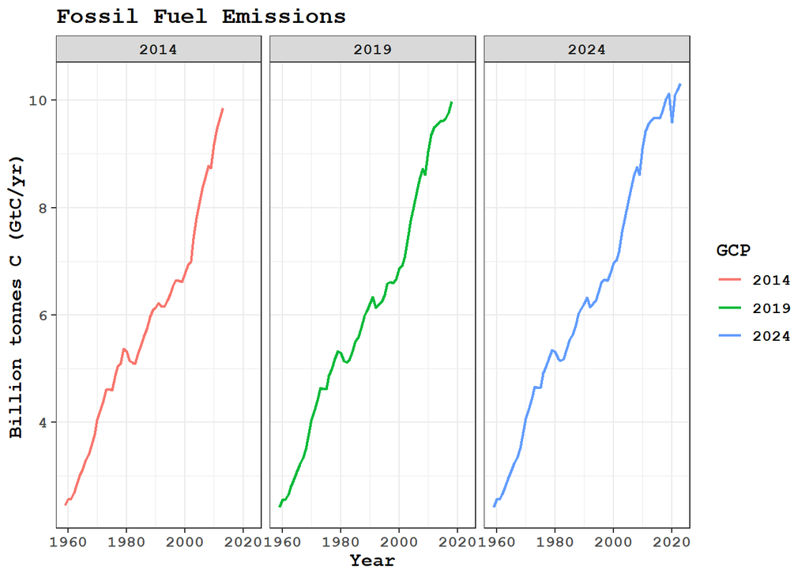

```r
data_FF$GCP <- as.factor(data_FF$GCP)
ggplot() +
  geom_line(data = data_FF,
            aes(year, value, color = GCP),
            linewidth = 0.8) +
  facet_wrap("GCP", scales = "fixed") +
  scale_color_discrete() +
  ggtitle("Fossil Fuel Emissions") +
  xlab("Year") +
  ylab("Billion tonnes C (GtC/yr)") +
  theme_bw() +
  theme(text = element_text(size = 12, family = "mono", face = "bold"))
```

Plot LUC emissions data for 3 key GCP releases (first year, historical extension, and most recent year)

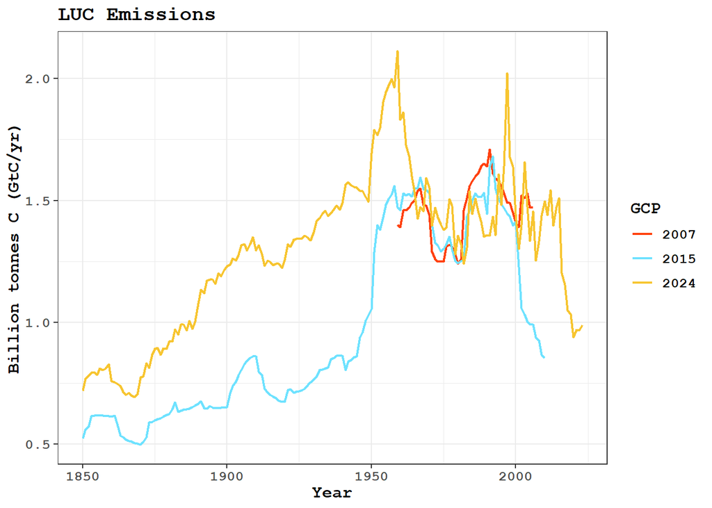

```r
LUC_results <- data %>% filter(GCP %in% c(2007, 2015, 2024))
LUC_results$GCP <- as.factor(LUC_results$GCP)
ggplot() +
  geom_line(data = LUC_results,
            aes(year, value, group = GCP, color = GCP),
            linewidth = 0.8) +
  ggtitle("LUC Emissions") +
  xlab("Year") +
  ylab("Billion tonnes C (GtC/yr)") +
  theme_bw() +
  theme(text = element_text(size = 12, family = "mono", face = "bold")) +
  scale_color_tron()
```

Basic Hector run

```r
library(hector)
ini_file <- system.file("input/hector_ssp245.ini", package = "hector")
core <- newcore(ini_file)
run(core)
```

```
## Hector core: Unnamed Hector core
## Start date:  1745
## End date:    2300
## Current date:    2300
## Input file:  C:\Users\tomb621\AppData\Local\R\win-library\4.5\hector\input\hector_ssp245.ini
```

```r
out_default <- fetchvars(core, 1850:2100, vars = c(CONCENTRATIONS_CO2(),
                                                   GLOBAL_TAS(),
                                                   VEG_C(),
                                                   SOIL_C(),
                                                   LUC_EMISSIONS()))
out_default$GCP <- "Hector Default"
```

LUC plot with Hector Default (SSP 2-45) as separate line

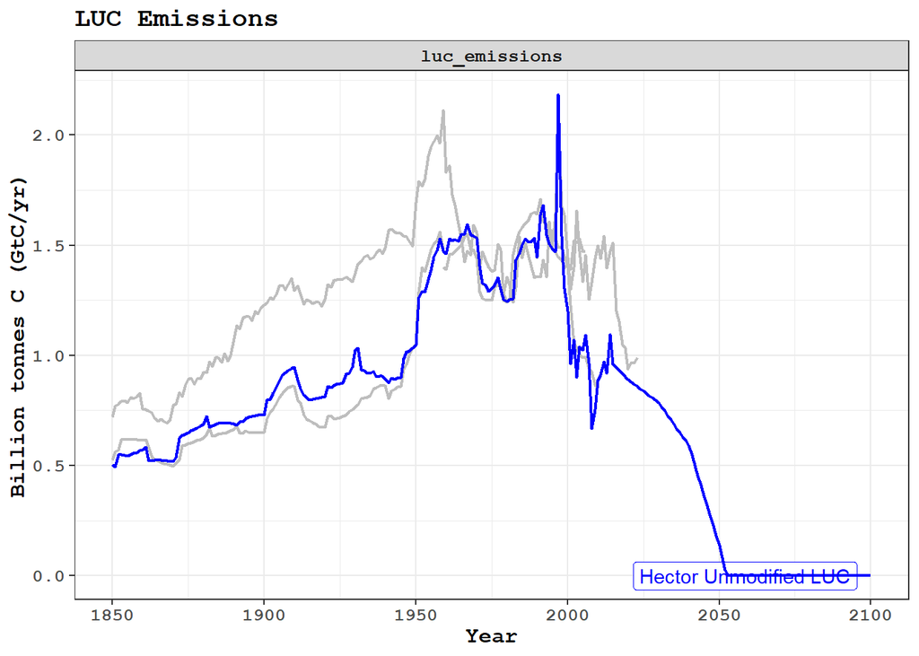

```r
LUC_default <- out_default %>%
  filter(variable == "luc_emissions")
ggplot() +
  geom_line(data = LUC_results,
            aes(year, value, group = GCP),
            color = "gray",
            linewidth = 0.8) +
  geom_label_repel(aes(label = "Hector Unmodified LUC"),
                   x = 2070,
                   y = 0.1,
                   color = "blue") +
  facet_wrap("variable", scales = "free") +
  geom_line(data = LUC_default,
            aes(year, value, group = GCP),
            color = "blue",
            linewidth = 0.8) +
  ggtitle("LUC Emissions") +
  xlab("Year") +
  ylab("Billion tonnes C (GtC/yr)") +
  theme_bw() +
  theme(text = element_text(size = 12, family = "mono", face = "bold"))
```

Create list and for loop to run all carbon budgets individually through Hector and extract projections for climate and carbon cycle variables and conditions

```r
all_gcp_years <- unique(data$GCP)
results <- list()
for(gcp_year in all_gcp_years){
  isolated_data <- data %>% filter(GCP == gcp_year)
  message("running ", gcp_year)
  message("I see ", nrow(isolated_data), " rows of data")
  setvar(core, isolated_data$year, LUC_EMISSIONS(), isolated_data$value,
         getunits(LUC_EMISSIONS()))
  reset(core)
  run(core)
  results[[as.character(gcp_year)]] <- fetchvars(core, 1850:2100, vars = c(CONCENTRATIONS_CO2(),
                                                                           GLOBAL_TAS(),
                                                                           VEG_C(),
                                                                           SOIL_C(),
                                                                           LUC_EMISSIONS(),
                                                                           OCEAN_C()))

}
```

```
## running 2007
```

```
## I see 48 rows of data
```

```
## running 2010
```

```
## I see 51 rows of data
```

```
## running 2015
```

```
## I see 161 rows of data
```

```
## running 2020
```

```
## I see 170 rows of data
```

```
## running 2023
```

```
## I see 173 rows of data
```

```
## running 2024
```

```
## I see 174 rows of data
```

Combine all data frames including the default model run into one large data frame

```r
results_gcp <- bind_rows(results, .id = "GCP")
results_df <- bind_rows(results_gcp, out_default)
head(results_df)
```

```
##    GCP            scenario year          variable    value    units
## 1 2007 Unnamed Hector core 1850 CO2_concentration 283.2175 ppmv CO2
## 2 2007 Unnamed Hector core 1851 CO2_concentration 283.5029 ppmv CO2
## 3 2007 Unnamed Hector core 1852 CO2_concentration 283.7846 ppmv CO2
## 4 2007 Unnamed Hector core 1853 CO2_concentration 284.0911 ppmv CO2
## 5 2007 Unnamed Hector core 1854 CO2_concentration 284.3687 ppmv CO2
## 6 2007 Unnamed Hector core 1855 CO2_concentration 284.6286 ppmv CO2
```

Plot global temperature projections

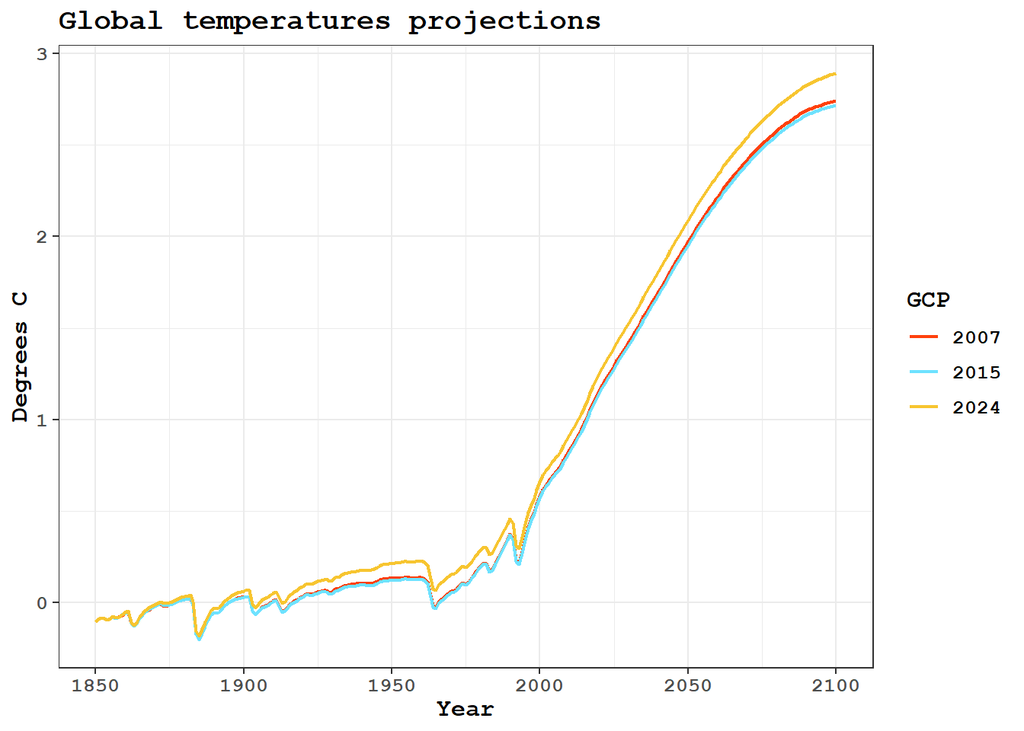

```r
projections_gcp <- results_df %>%
  filter(variable == "global_tas") %>%
  filter(GCP %in% c(2007, 2015, 2024))
projections_default <-  results_df %>%
  filter(variable == "global_tas") %>%
  filter(GCP == "Hector Default")
ggplot() +
  geom_line(data = projections_gcp,
            aes(year, value, color = GCP),
            linewidth = 0.8) +
  #facet_wrap("variable", scales = "free") +
  #geom_line(data = projections_default,
            #aes(year, value),
            #color = "pink",
            #linewidth = 0.8) +
  ggtitle("Global temperatures projections") +
  xlab("Year") +
  ylab("Degrees C") +
  theme_bw() +
  theme(text = element_text(size = 12, family = "mono", face = "bold")) +
  scale_color_tron()
```

Calculate projection uncertainty due to LUC emissions revisions and store in hector_uncertainty

```r
hector_uncertainty <- results_df %>%
  filter(year %in% c(2024, 2100)) %>%
  filter(variable %in% c("global_tas", "CO2_concentration")) %>%
  group_by(year, variable) %>%
  summarise(
    mean_value = mean(value),
    sd_value = sd(value),
    margin_error = 1.96 * (sd_value/sqrt(length(unique(results_df$GCP)))),
    spread = max(value) - min(value)
  )
```

Relative graph showing deviation each projection has from the average of all temperature projections

```r
results_temp <- results_df %>%
  filter(variable == "global_tas")
results_avg <- results_temp %>%
  group_by(year) %>%
  summarize(mean_value = mean(value))
full_df <- left_join(results_temp, results_avg, by = "year")
diff <- mutate(full_df, subtract = value - mean_value)
tail(diff)
```

```
##                 GCP            scenario year   variable    value units
## 1752 Hector Default Unnamed Hector core 2095 global_tas 2.701186  degC
## 1753 Hector Default Unnamed Hector core 2096 global_tas 2.706050  degC
## 1754 Hector Default Unnamed Hector core 2097 global_tas 2.710481  degC
## 1755 Hector Default Unnamed Hector core 2098 global_tas 2.714499  degC
## 1756 Hector Default Unnamed Hector core 2099 global_tas 2.718119  degC
## 1757 Hector Default Unnamed Hector core 2100 global_tas 2.721352  degC
##      mean_value    subtract
## 1752   2.766486 -0.06529965
## 1753   2.771792 -0.06574168
## 1754   2.776669 -0.06618794
## 1755   2.781137 -0.06663729
## 1756   2.785211 -0.06709258
## 1757   2.788905 -0.06755250
```

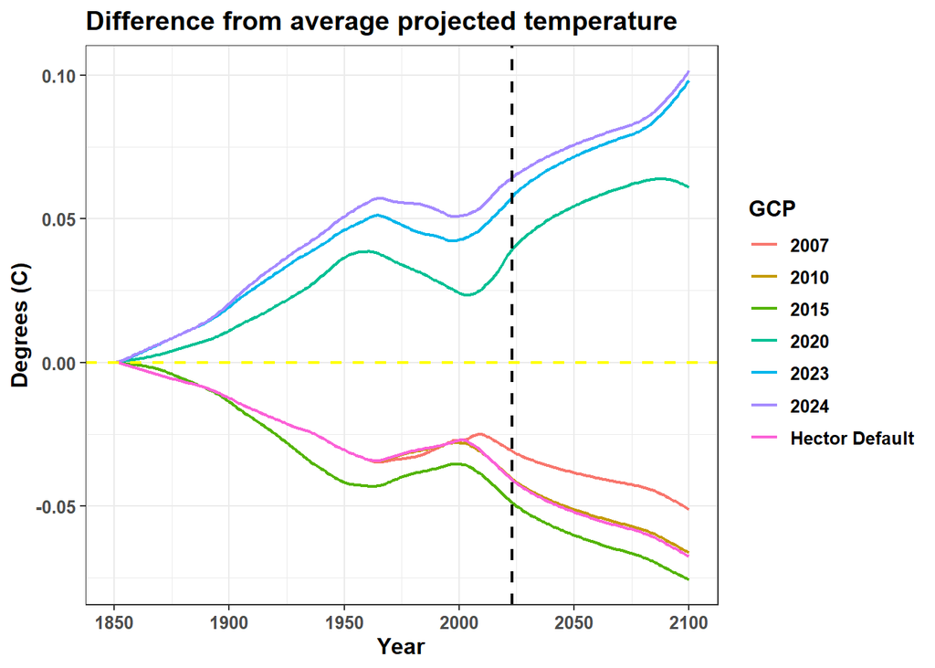

```r
ggplot() +
  geom_line(data = diff,
            aes(year, subtract, color = GCP),
            linewidth = 0.8) +
  geom_vline(xintercept = 2023, linetype = "dashed", color = "black", linewidth = 0.8) +
  geom_hline(yintercept = 0, linetype = "dashed", color = "yellow", linewidth = 0.8) +
  xlab("Year") +
  ylab("Degrees (C)") +
  ggtitle("Difference from average projected temperature") +
  theme_bw() +
  theme(text = element_text(size = 12, family = "sans", face = "bold"))
```

Ocean, soil, and vegetation carbon plots to determine the driver of long-lasting LUC effects

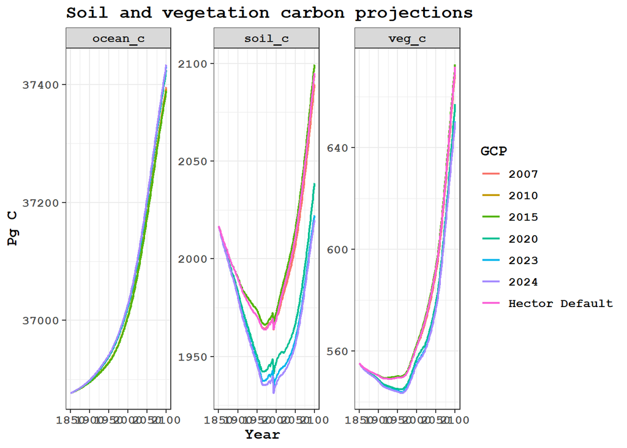

```r
soil_veg <- results_df %>%
  filter(variable %in% c("soil_c", "veg_c", "ocean_c"))
ggplot() +
  geom_line(data = soil_veg,
          aes(year, value, color = GCP),
          linewidth = 0.8) +
  facet_wrap("variable", scales = "free") +
  ggtitle("Soil and vegetation carbon projections") +
  xlab("Year") +
  ylab("Pg C") +
  theme_bw() +
  theme(text = element_text(size = 12, family = "mono", face = "bold"))
```

Matilda Analysis (parametric uncertainty) and calculating 95% confidence interval for 100 Matilda runs. This was used to compare how uncertainty of historical LUC emissions and uncertainty of parameters each contributes to overall CO2 projection uncertainty

```r
library(matilda)
ini_file <- system.file("input/hector_ssp245.ini", package = "hector")
core <- newcore(ini_file)
param_sets <- generate_params(core, draws = 100)
print(param_sets)
```

```
##          BETA    Q10_RH NPP_FLUX0 AERO_SCALE DIFFUSIVITY      ECS
## 1   0.5963838 2.0327171  47.86719  1.2695849    2.405121 2.143206
## 2   0.5282542 3.2334935  50.74918  1.1047917    2.289715 2.254056
## 3   0.6307020 1.6394590  72.58560  1.4320777    2.615719 1.988943
## 4   0.4288873 1.5779007  61.40092  0.9280664    2.388033 3.224917
## 5   0.5352913 1.0478964  71.64456  0.8372057    2.374959 4.415603
## 6   0.5392080 0.7412125  45.92685  0.8558613    2.458738 2.437138
## 7   0.5935739 0.4002846  62.96286  1.0578598    2.486375 3.191737
## 8   0.5676793 4.3453115  59.93137  1.0387280    2.242605 2.810439
## 9   0.4075821 4.0554077  67.64523  0.9124836    2.497379 3.657563
## 10  0.5517804 1.1564168  60.88752  0.5738209    2.350491 2.144128
## 11  0.5986025 2.4881907  67.30546  1.1062642    2.363637 2.115922
## 12  0.5529940 2.4633935  44.18993  1.0410733    2.416417 2.784891
## 13  0.6293692 1.4007063  60.26899  1.1607799    2.513300 3.552946
## 14  0.5171925 1.8001323  57.09361  1.1677099    2.314092 2.567052
```

[output cut: 86 more lines]

```r
m_results <- iterate_model(core,
                         params = param_sets,
                         save_vars = c("CO2_concentration"), save_years = 1850:2100)
```

[output not shown]

[output not shown]

[output not shown]

[output not shown]

[output not shown]

[output not shown]

[output not shown]

[output not shown]

[output not shown]

[output not shown]

[output not shown]

[output not shown]

[output not shown]

[output not shown]

[output not shown]

[output not shown]

[output not shown]

[output not shown]

[output not shown]

[output not shown]

[output not shown]

[output not shown]

[output not shown]

[output not shown]

[output not shown]

[output not shown]

[output not shown]

[output not shown]

[output not shown]

[output not shown]

[output not shown]

[output not shown]

[output not shown]

[output not shown]

[output not shown]

[output not shown]

[output not shown]

[output not shown]

[output not shown]

[output not shown]

[output not shown]

[output not shown]

[output not shown]

[output not shown]

[output not shown]

[output not shown]

[output not shown]

[output not shown]

[output not shown]

[output not shown]

[output not shown]

[output not shown]

[output not shown]

[output not shown]

[output not shown]

[output not shown]

[output not shown]

[output not shown]

[output not shown]

[output not shown]

[output not shown]

[output not shown]

[output not shown]

[output not shown]

[output not shown]

[output not shown]

[output not shown]

[output not shown]

[output not shown]

[output not shown]

[output not shown]

[output not shown]

[output not shown]

[output not shown]

[output not shown]

[output not shown]

[output not shown]

[output not shown]

[output not shown]

[output not shown]

[output not shown]

[output not shown]

[output not shown]

[output not shown]

[output not shown]

[output not shown]

[output not shown]

[output not shown]

[output not shown]

[output not shown]

[output not shown]

[output not shown]

[output not shown]

[output not shown]

[output not shown]

[output not shown]

[output not shown]

[output not shown]

[output not shown]

[output not shown]

[output not shown]

[output not shown]

[output not shown]

[output not shown]

[output not shown]

[output not shown]

[output not shown]

[output not shown]

[output not shown]

[output not shown]

[output not shown]

[output not shown]

[output not shown]

[output not shown]

[output not shown]

[output not shown]

[output not shown]

[output not shown]

[output not shown]

[output not shown]

[output not shown]

[output not shown]

[output not shown]

[output not shown]

[output not shown]

[output not shown]

[output not shown]

[output not shown]

[output not shown]

[output not shown]

[output not shown]

[output not shown]

[output not shown]

[output not shown]

[output not shown]

[output not shown]

[output not shown]

[output not shown]

[output not shown]

[output not shown]

[output not shown]

[output not shown]

[output not shown]

[output not shown]

[output not shown]

[output not shown]

[output not shown]

[output not shown]

[output not shown]

[output not shown]

[output not shown]

[output not shown]

[output not shown]

[output not shown]

[output not shown]

[output not shown]

[output not shown]

[output not shown]

[output not shown]

[output not shown]

[output not shown]

[output not shown]

[output not shown]

[output not shown]

[output not shown]

[output not shown]

[output not shown]

[output not shown]

[output not shown]

[output not shown]

[output not shown]

[output not shown]

[output not shown]

[output not shown]

[output not shown]

[output not shown]

[output not shown]

[output not shown]

[output not shown]

[output not shown]

[output not shown]

[output not shown]

[output not shown]

[output not shown]

[output not shown]

[output not shown]

[output not shown]

[output not shown]

[output not shown]

[output not shown]

[output not shown]

[output not shown]

[output not shown]

[output not shown]

[output not shown]

[output not shown]

[output not shown]

[output not shown]

[output not shown]

[output not shown]

[output not shown]

[output not shown]

[output not shown]

[output not shown]

[output not shown]

[output not shown]

[output not shown]

[output not shown]

[output not shown]

[output not shown]

[output not shown]

[output not shown]

[output not shown]

[output not shown]

[output not shown]

[output not shown]

[output not shown]

[output not shown]

[output not shown]

[output not shown]

[output not shown]

[output not shown]

[output not shown]

[output not shown]

[output not shown]

[output not shown]

[output not shown]

[output not shown]

[output not shown]

[output not shown]

[output not shown]

[output not shown]

[output not shown]

[output not shown]

[output not shown]

[output not shown]

[output not shown]

[output not shown]

[output not shown]

[output not shown]

[output not shown]

[output not shown]

[output not shown]

[output not shown]

[output not shown]

[output not shown]

[output not shown]

[output not shown]

[output not shown]

[output not shown]

[output not shown]

[output not shown]

[output not shown]

[output not shown]

[output not shown]

[output not shown]

[output not shown]

[output not shown]

[output not shown]

[output not shown]

[output not shown]

[output not shown]

[output not shown]

[output not shown]

[output not shown]

[output not shown]

[output not shown]

[output not shown]

[output not shown]

[output not shown]

[output not shown]

[output not shown]

[output not shown]

[output not shown]

[output not shown]

[output not shown]

[output not shown]

[output not shown]

[output not shown]

[output not shown]

[output not shown]

[output not shown]

[output not shown]

[output not shown]

[output not shown]

[output not shown]

[output not shown]

[output not shown]

[output not shown]

[output not shown]

[output not shown]

[output not shown]

[output not shown]

[output not shown]

[output not shown]

[output not shown]

[output not shown]

[output not shown]

[output not shown]

[output not shown]

[output not shown]

[output not shown]

[output not shown]

[output not shown]

[output not shown]

[output not shown]

[output not shown]

[output not shown]

[output not shown]

[output not shown]

[output not shown]

[output not shown]

[output not shown]

[output not shown]

[output not shown]

[output not shown]

[output not shown]

[output not shown]

[output not shown]

[output not shown]

[output not shown]

[output not shown]

[output not shown]

[output not shown]

[output not shown]

[output not shown]

[output not shown]

[output not shown]

[output not shown]

[output not shown]

[output not shown]

[output not shown]

[output not shown]

[output not shown]

[output not shown]

[output not shown]

[output not shown]

[output not shown]

[output not shown]

[output not shown]

[output not shown]

[output not shown]

[output not shown]

[output not shown]

[output not shown]

[output not shown]

[output not shown]

[output not shown]

[output not shown]

[output not shown]

[output not shown]

[output not shown]

[output not shown]

[output not shown]

[output not shown]

[output not shown]

[output not shown]

[output not shown]

[output not shown]

[output not shown]

[output not shown]

[output not shown]

[output not shown]

[output not shown]

[output not shown]

[output not shown]

[output not shown]

[output not shown]

[output not shown]

[output not shown]

[output not shown]

[output not shown]

[output not shown]

[output not shown]

[output not shown]

[output not shown]

[output not shown]

[output not shown]

[output not shown]

[output not shown]

[output not shown]

[output not shown]

[output not shown]

[output not shown]

[output not shown]

[output not shown]

[output not shown]

[output not shown]

[output not shown]

[output not shown]

[output not shown]

[output not shown]

[output not shown]

[output not shown]

[output not shown]

[output not shown]

[output not shown]

[output not shown]

[output not shown]

[output not shown]

[output not shown]

[output not shown]

[output not shown]

[output not shown]

[output not shown]

[output not shown]

[output not shown]

[output not shown]

[output not shown]

[output not shown]

[output not shown]

[output not shown]

[output not shown]

[output not shown]

[output not shown]

[output not shown]

[output not shown]

[output not shown]

[output not shown]

[output not shown]

[output not shown]

[output not shown]

[output not shown]

[output not shown]

[output not shown]

[output not shown]

[output not shown]

[output not shown]

[output not shown]

[output not shown]

[output not shown]

[output not shown]

[output not shown]

[output not shown]

[output not shown]

[output not shown]

[output not shown]

[output not shown]

[output not shown]

[output not shown]

[output not shown]

[output not shown]

[output not shown]

[output not shown]

[output not shown]

[output not shown]

[output not shown]

[output not shown]

[output not shown]

[output not shown]

[output not shown]

[output not shown]

[output not shown]

[output not shown]

[output not shown]

[output not shown]

[output not shown]

[output not shown]

[output not shown]

[output not shown]

[output not shown]

[output not shown]

[output not shown]

[output not shown]

[output not shown]

[output not shown]

[output not shown]

[output not shown]

[output not shown]

[output not shown]

[output not shown]

[output not shown]

[output not shown]

[output not shown]

[output not shown]

[output not shown]

[output not shown]

[output not shown]

[output not shown]

[output not shown]

[output not shown]

[output not shown]

[output not shown]

[output not shown]

[output not shown]

[output not shown]

[output not shown]

[output not shown]

[output not shown]

[output not shown]

[output not shown]

[output not shown]

[output not shown]

[output not shown]

[output not shown]

[output not shown]

[output not shown]

[output not shown]

[output not shown]

[output not shown]

[output not shown]

[output not shown]

[output not shown]

[output not shown]

[output not shown]

[output not shown]

[output not shown]

[output not shown]

[output not shown]

[output not shown]

[output not shown]

[output not shown]

[output not shown]

[output not shown]

[output not shown]

[output not shown]

[output not shown]

[output not shown]

[output not shown]

[output not shown]

[output not shown]

[output not shown]

[output not shown]

[output not shown]

[output not shown]

[output not shown]

[output not shown]

[output not shown]

[output not shown]

[output not shown]

[output not shown]

[output not shown]

[output not shown]

[output not shown]

[output not shown]

[output not shown]

[output not shown]

[output not shown]

[output not shown]

[output not shown]

[output not shown]

[output not shown]

[output not shown]

[output not shown]

[output not shown]

[output not shown]

[output not shown]

[output not shown]

[output not shown]

[output not shown]

[output not shown]

[output not shown]

[output not shown]

[output not shown]

[output not shown]

[output not shown]

[output not shown]

[output not shown]

[output not shown]

[output not shown]

[output not shown]

[output not shown]

[output not shown]

[output not shown]

[output not shown]

[output not shown]

[output not shown]

[output not shown]

[output not shown]

[output not shown]

[output not shown]

[output not shown]

[output not shown]

[output not shown]

[output not shown]

[output not shown]

[output not shown]

[output not shown]

[output not shown]

[output not shown]

[output not shown]

[output not shown]

[output not shown]

[output not shown]

[output not shown]

[output not shown]

[output not shown]

[output not shown]

[output not shown]

[output not shown]

[output not shown]

[output not shown]

[output not shown]

[output not shown]

[output not shown]

[output not shown]

[output not shown]

[output not shown]

[output not shown]

[output not shown]

```r
head(m_results)
```

```
##              scenario year          variable    value    units run_number
## 1 Unnamed Hector core 1850 CO2_concentration 283.6187 ppmv CO2          1
## 2 Unnamed Hector core 1851 CO2_concentration 283.9007 ppmv CO2          1
## 3 Unnamed Hector core 1852 CO2_concentration 284.1792 ppmv CO2          1
## 4 Unnamed Hector core 1853 CO2_concentration 284.4824 ppmv CO2          1
## 5 Unnamed Hector core 1854 CO2_concentration 284.7561 ppmv CO2          1
## 6 Unnamed Hector core 1855 CO2_concentration 285.0125 ppmv CO2          1
```

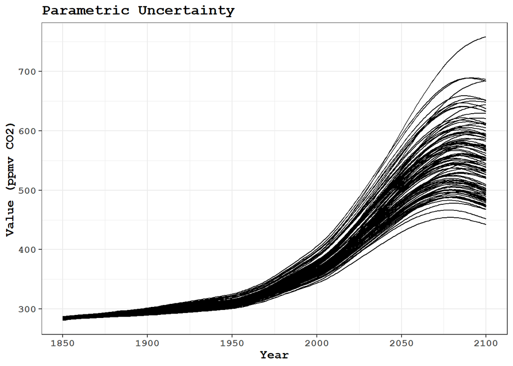

```r
ggplot() +
  geom_line(data = m_results,
            aes(year, value, group = run_number)) +
  xlab("Year") +
  ylab("Value (ppmv CO2)") +
  ggtitle("Parametric Uncertainty") +
  theme_bw() +
  theme(text = element_text(size = 12, family = "mono", face = "bold"))
```

```r
matilda_uncertainty <- m_results %>%
  filter(year %in% c(2024, 2100)) %>%
  group_by(year, variable) %>%
  summarise(
    mean_value = mean(value),
    sd_value = sd(value),
    margin_error = 1.96 * (sd_value/10),
    spread = max(value) - min(value)
  )
```